# RStudio Datasets

### BOD

**Loading Data / Basic Plotting Tutorial**

```r
library(ggplot2) #qplot (basic scatterplot)
library(ggthemes)
library(tidyverse)
library(datasets)
library(ggfortify)
```

?datasets library(help = “datasets”) ?BOD

BOD head(BOD)

class(BOD) #data frame

#same thing as basic ggplot

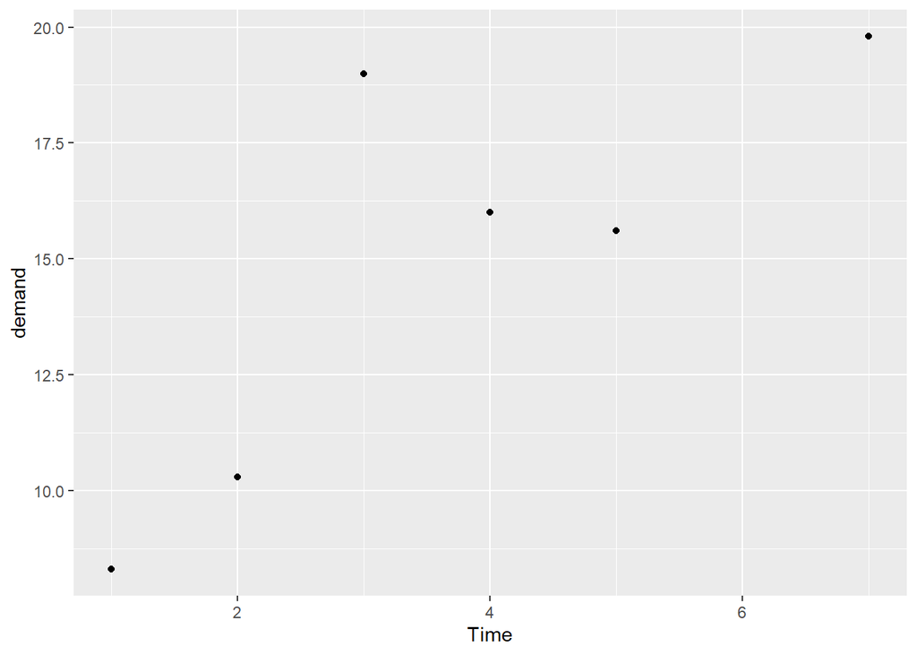

```r
qplot(Time, demand, data=BOD)
```

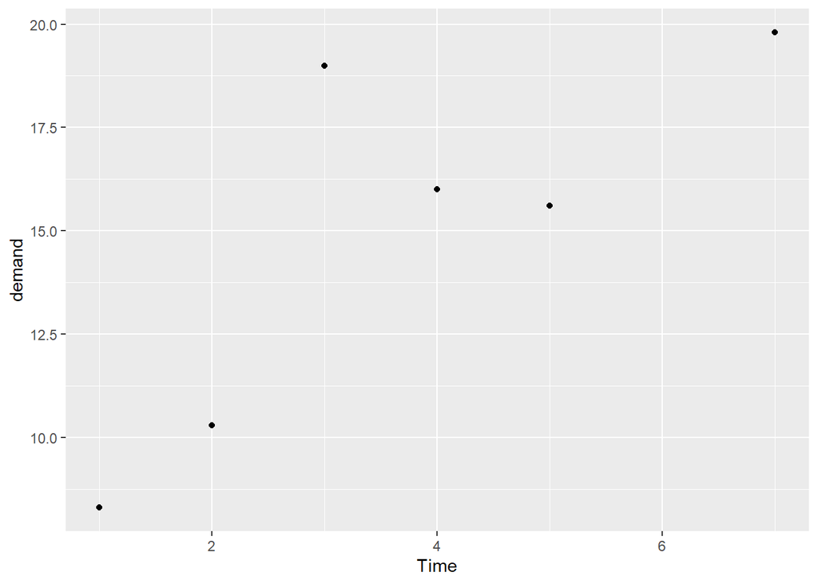

```r
ggplot(BOD, aes(Time, demand))+
  geom_point()
```

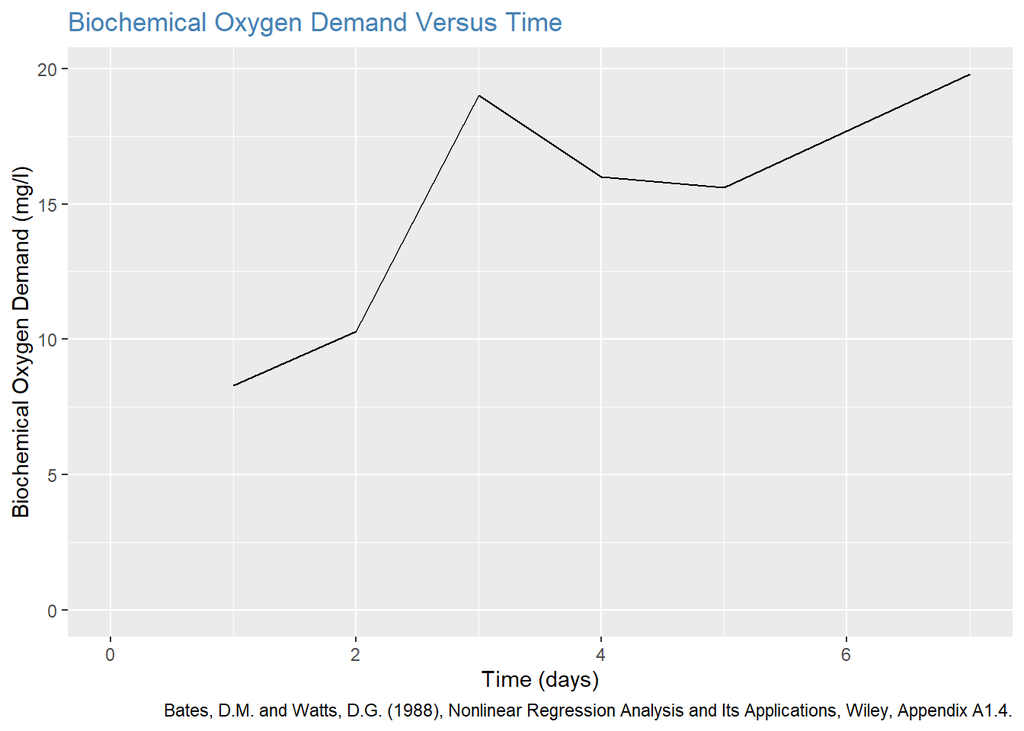

```r
ggplot(BOD, aes(Time, demand))+
  geom_line()+
  expand_limits(y=0, x=0)+
  labs(title="Biochemical Oxygen Demand Versus Time", x = "Time (days)", y = "Biochemical Oxygen Demand (mg/l)",
       caption="Bates, D.M. and Watts, D.G. (1988), Nonlinear Regression Analysis and Its Applications, Wiley, Appendix A1.4.")+
  theme(plot.title = element_text(color = "SteelBlue"))
```

### CO2

**Loading Data / Basic Plotting Tutorial**

```r
library(ggplot2) #qplot (basic scatterplot)
library(ggthemes)
library(tidyverse)
library(datasets)
library(ggfortify)
```

?datasets library(help = “datasets”) ?CO2

CO2 head(CO2)

class(CO2) #data frame

same thing as basic ggplot

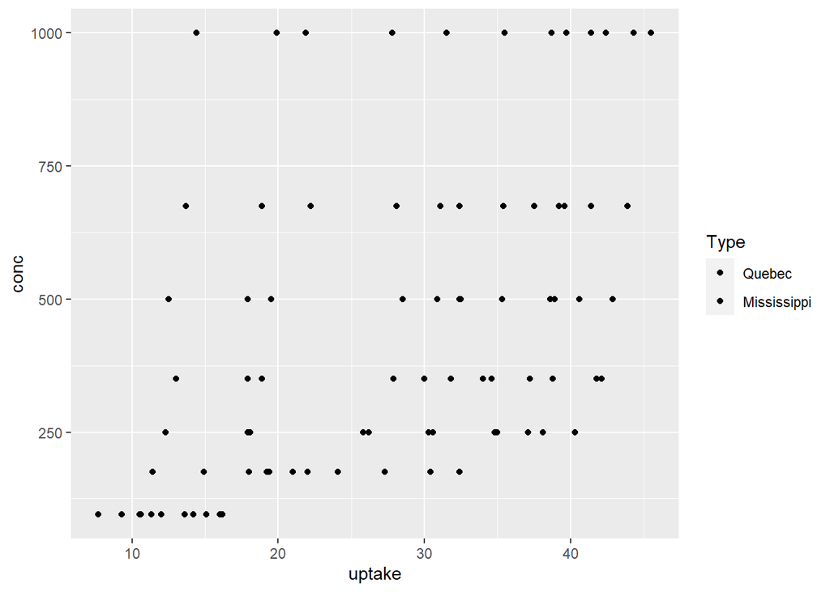

```r
qplot(uptake, conc, data=CO2, fill=Type)
```

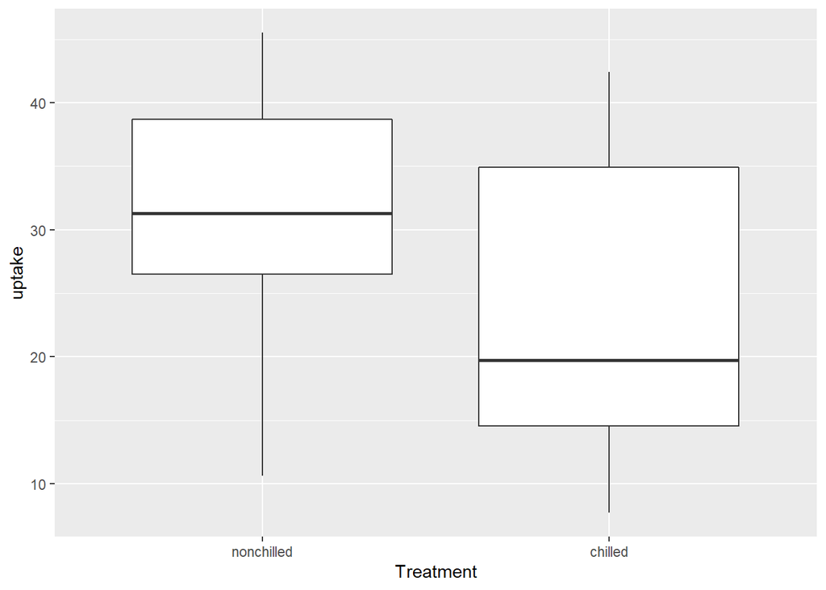

```r
ggplot(CO2, aes(x=Treatment, y=uptake)) +
  geom_boxplot()
```

```r
t.test(CO2$uptake ~ CO2$Treatment)
```

```
##
##  Welch Two Sample t-test
##
## data:  CO2$uptake by CO2$Treatment
## t = 3.0485, df = 80.945, p-value = 0.003107
## alternative hypothesis: true difference in means between group nonchilled and group chilled is not equal to 0
## 95 percent confidence interval:
##   2.382366 11.336682
## sample estimates:
## mean in group nonchilled    mean in group chilled
##                 30.64286                 23.78333
```

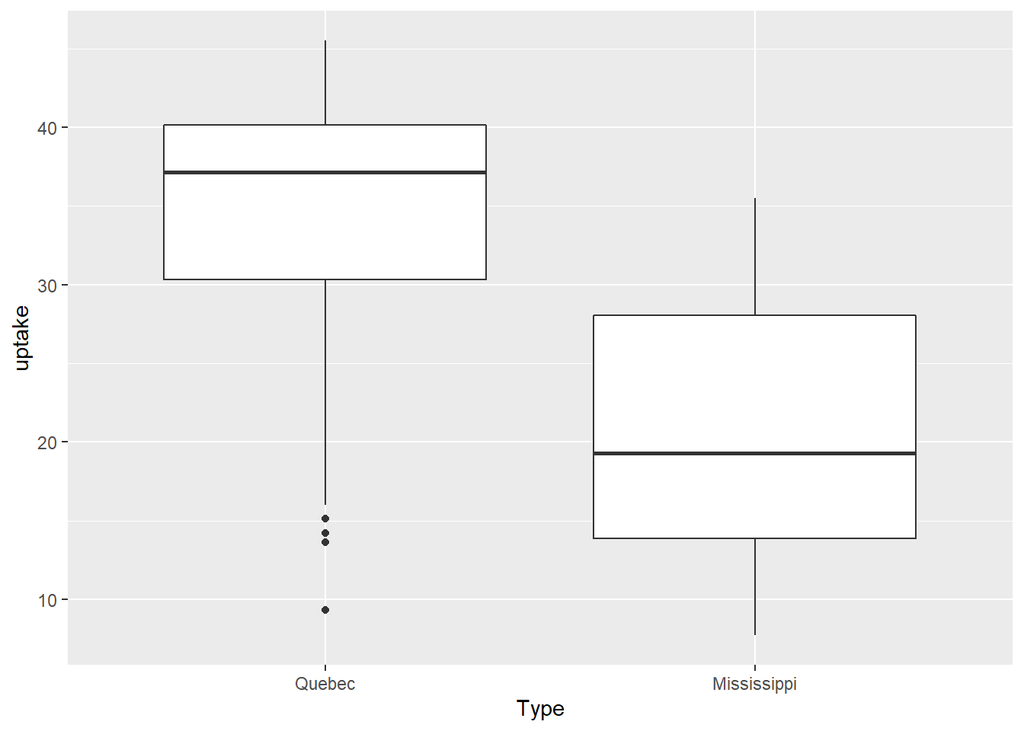

```r
ggplot(CO2, aes(x=Type, y=uptake)) +
  geom_boxplot()
```

```r
t.test(CO2$uptake ~ CO2$Type)
```

```
##
##  Welch Two Sample t-test
##
## data:  CO2$uptake by CO2$Type
## t = 6.5969, df = 78.533, p-value = 4.451e-09
## alternative hypothesis: true difference in means between group Quebec and group Mississippi is not equal to 0
## 95 percent confidence interval:
##   8.839475 16.479572
## sample estimates:
##      mean in group Quebec mean in group Mississippi
##                  33.54286                  20.88333
```

set the plotting area into a 1*2 array

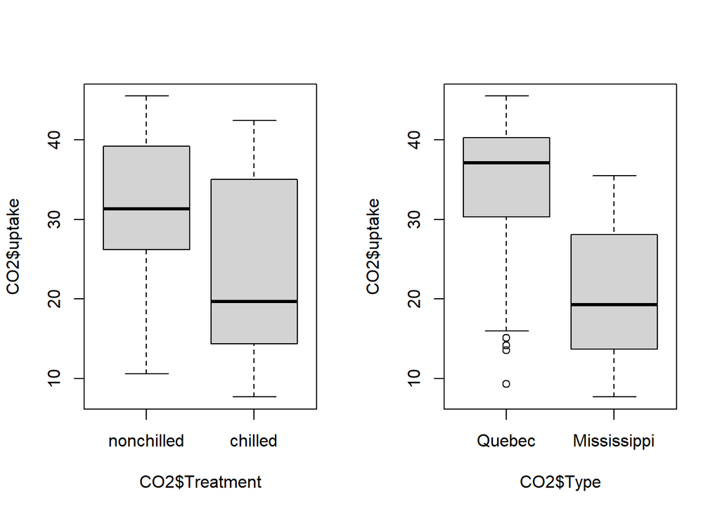

```r
par(mfrow = c(1,2))
boxplot(CO2$uptake ~ CO2$Treatment)
boxplot(CO2$uptake ~ CO2$Type)
```

set the plotting area into a 1*1 array

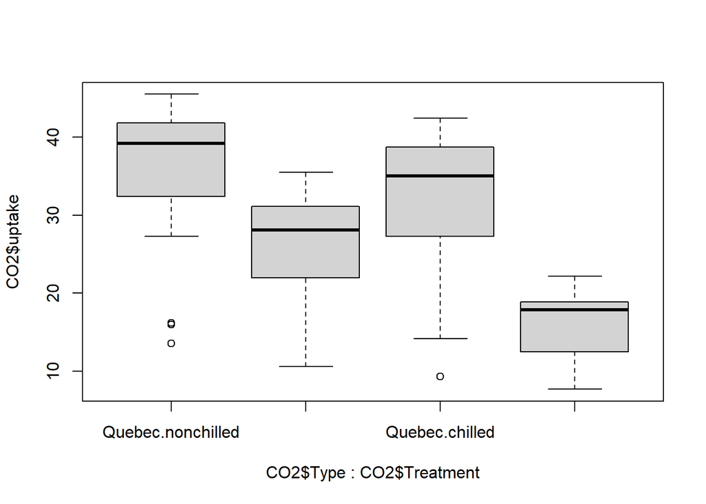

```r
par(mfrow = c(1,1))
boxplot(CO2$uptake ~ CO2$Type + CO2$Treatment)
```

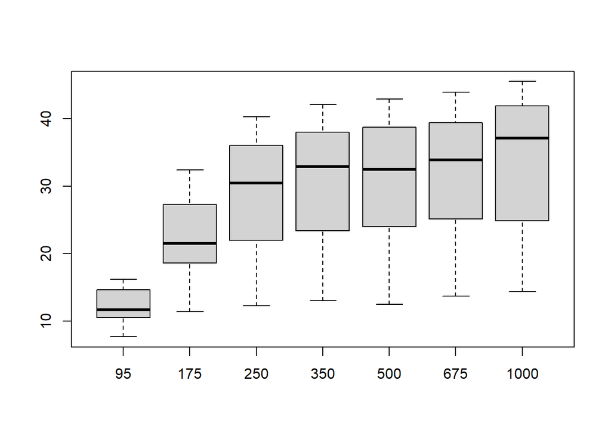

```r
par(mfrow = c(1,1))
boxplot(subset(CO2$uptake, CO2$conc == 95),
        subset(CO2$uptake, CO2$conc == 175),
        subset(CO2$uptake, CO2$conc == 250),
        subset(CO2$uptake, CO2$conc == 350),
        subset(CO2$uptake, CO2$conc == 500),
        subset(CO2$uptake, CO2$conc == 675),
        subset(CO2$uptake, CO2$conc == 1000),
        names = c("95", "175", "250", "350", "500", "675", "1000"))
```

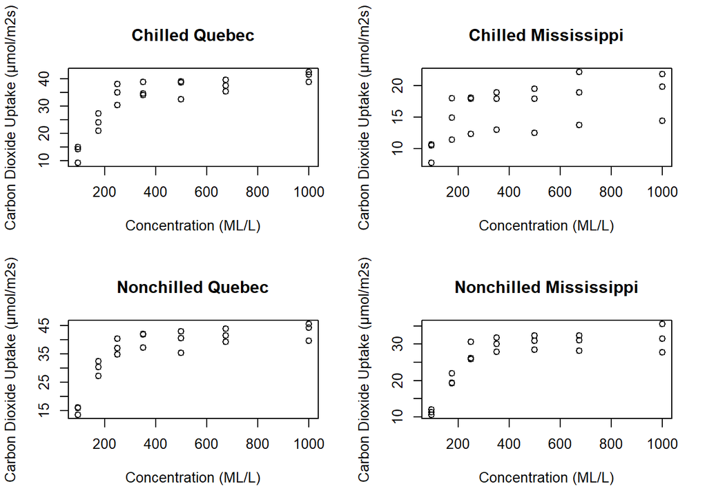

```r
par(mfrow = c(2,2))
plot(uptake ~ conc, data = subset(CO2,Type == "Quebec" & Treatment == "chilled"),
     main="Chilled Quebec", xlab = "Concentration (ML/L)", ylab = "Carbon Dioxide Uptake (μmol/m2s)" )
plot(uptake ~ conc, data = subset(CO2,Type == "Mississippi" & Treatment == "chilled"),
     main="Chilled Mississippi", xlab = "Concentration (ML/L)", ylab = "Carbon Dioxide Uptake (μmol/m2s)")
plot(uptake ~ conc, data = subset(CO2,Type == "Quebec" & Treatment == "nonchilled"),
     main="Nonchilled Quebec", xlab = "Concentration (ML/L)", ylab = "Carbon Dioxide Uptake (μmol/m2s)")
plot(uptake ~ conc, data = subset(CO2,Type == "Mississippi" & Treatment == "nonchilled"),
     main="Nonchilled Mississippi", xlab = "Concentration (ML/L)", ylab = "Carbon Dioxide Uptake (μmol/m2s)")
```

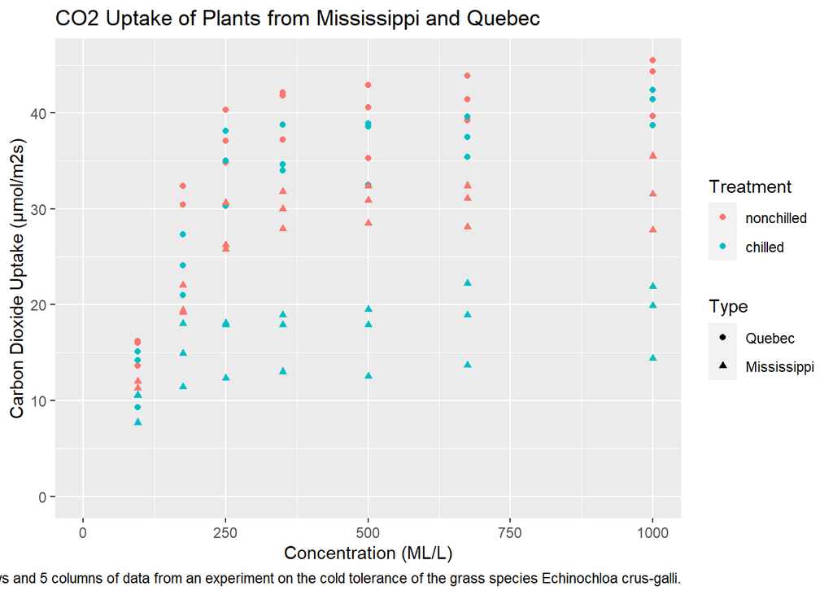

```r
ggplot(CO2, aes(conc, uptake, color=Treatment, shape=Type)) +
  geom_point()+
  expand_limits(y=0, x=0)+
  labs(title="CO2 Uptake of Plants from Mississippi and Quebec", x = "Concentration (ML/L)", y = "Carbon Dioxide Uptake (μmol/m2s)",
       caption="The CO2 data frame has 84 rows and 5 columns of data from an experiment on the cold tolerance of the grass species Echinochloa crus-galli.")
```

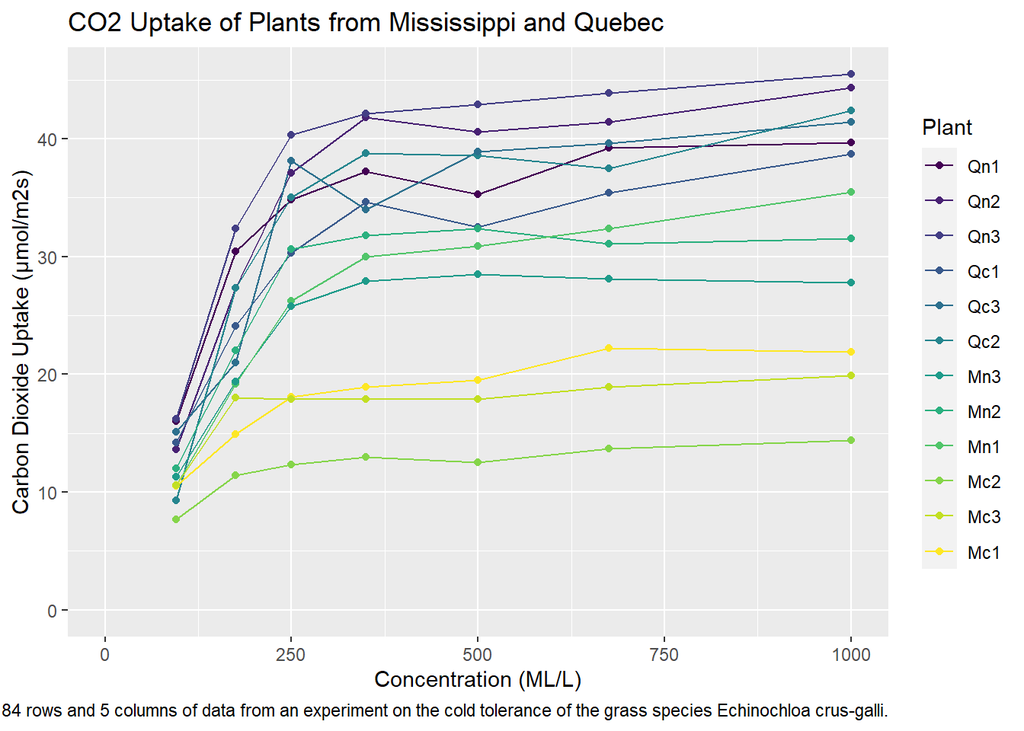

```r
ggplot(CO2, aes(conc, uptake, color=Plant, type=Treatment)) +
  geom_line()+
  geom_point()+
  expand_limits(y=0, x=0)+
  labs(title="CO2 Uptake of Plants from Mississippi and Quebec", x = "Concentration (ML/L)", y = "Carbon Dioxide Uptake (μmol/m2s)",
       caption="The CO2 data frame has 84 rows and 5 columns of data from an experiment on the cold tolerance of the grass species Echinochloa crus-galli.")
```

### ChickWeight

**Loading Data / Basic Plotting Tutorial**

```r
library(ggplot2) #qplot (basic scatterplot)
library(ggthemes)
library(tidyverse)
library(datasets)
library(ggfortify)
library(rmarkdown)
```

?datasets library(help = “datasets”) ?ChickWeight

ChickWeight head(ChickWeight)

class(ChickWeight) #data frame

The body weights of the chicks were measured at birth and every second day thereafter until day 20. They were also measured on day 21. There were four groups on chicks on different protein diets.

tail(ChickWeight)

```r
chick0 <- ChickWeight[ChickWeight$Time %in% 0:5, ]
chick1 <- ChickWeight[ChickWeight$Time %in% 6:10, ]
chick2 <- ChickWeight[ChickWeight$Time %in% 11:15, ]
chick3 <- ChickWeight[ChickWeight$Time %in% 16:21, ]
```

chick0 chick1 chick2 chick3

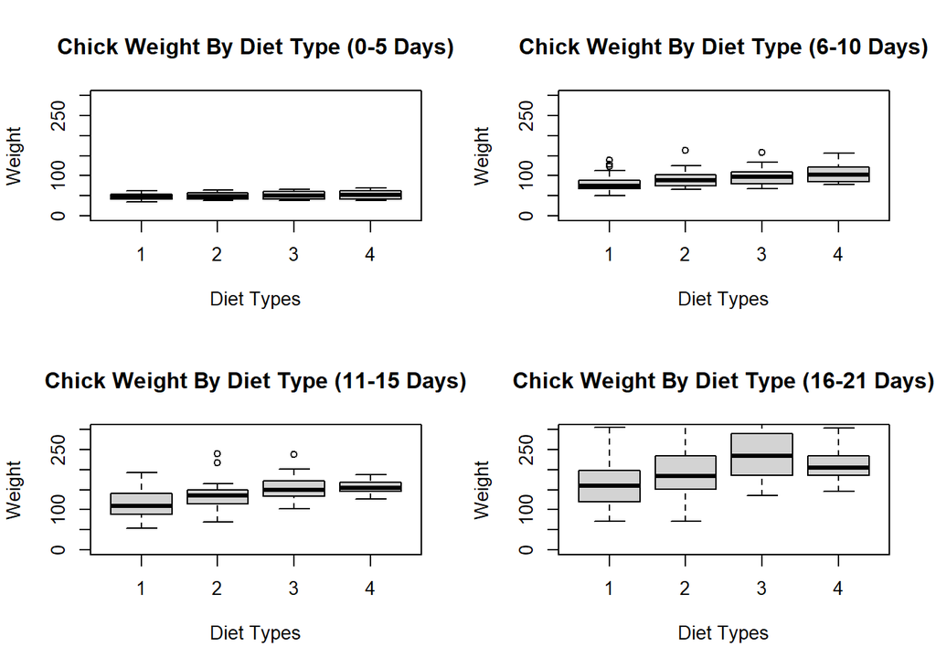

```r
par(mfrow = c(2,2))
boxplot(chick0$weight ~ chick0$Diet,
        main = "Chick Weight By Diet Type (0-5 Days)",
        xlab = "Diet Types",
        ylab = "Weight",
        ylim = c(0, 300))
boxplot(chick1$weight ~ chick1$Diet,
        main = "Chick Weight By Diet Type (6-10 Days)",
        xlab = "Diet Types",
        ylab = "Weight",
        ylim = c(0, 300))
boxplot(chick2$weight ~ chick2$Diet,
        main = "Chick Weight By Diet Type (11-15 Days)",
        xlab = "Diet Types",
        ylab = "Weight",
        ylim = c(0, 300))
boxplot(chick3$weight ~ chick3$Diet,
        main = "Chick Weight By Diet Type (16-21 Days)",
        xlab = "Diet Types",
        ylab = "Weight",
        ylim = c(0, 300))
```

```r
chickDiet1 <- ChickWeight[ChickWeight$Diet == 1, ]
chickDiet2 <- ChickWeight[ChickWeight$Diet == 2, ]
chickDiet3 <- ChickWeight[ChickWeight$Diet == 3, ]
chickDiet4 <- ChickWeight[ChickWeight$Diet == 4, ]
```

chickDiet1 chickDiet2 chickDiet3 chickDiet4

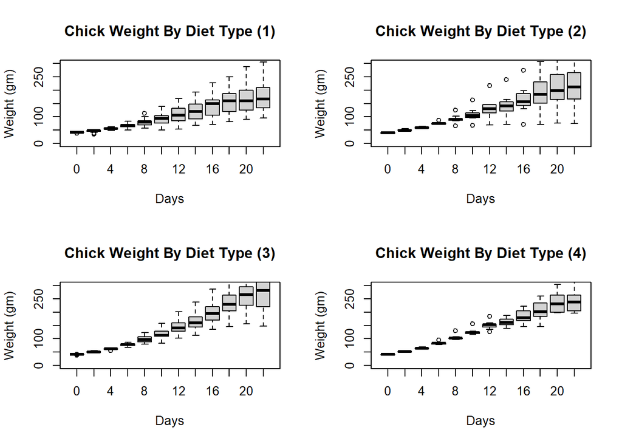

```r
par(mfrow = c(2,2))
boxplot(chickDiet1$weight ~ chickDiet1$Time,
        main = "Chick Weight By Diet Type (1)",
        xlab = "Days",
        ylab = "Weight (gm)",
        ylim = c(0, 300))
boxplot(chickDiet2$weight ~ chickDiet2$Time,
        main = "Chick Weight By Diet Type (2)",
        xlab = "Days",
        ylab = "Weight (gm)",
        ylim = c(0, 300))
boxplot(chickDiet3$weight ~ chickDiet3$Time,
        main = "Chick Weight By Diet Type (3)",
        xlab = "Days",
        ylab = "Weight (gm)",
        ylim = c(0, 300))
boxplot(chickDiet4$weight ~ chickDiet4$Time,
        main = "Chick Weight By Diet Type (4)",
        xlab = "Days",
        ylab = "Weight (gm)",
        ylim = c(0, 300))
```

same thing as basic ggplot

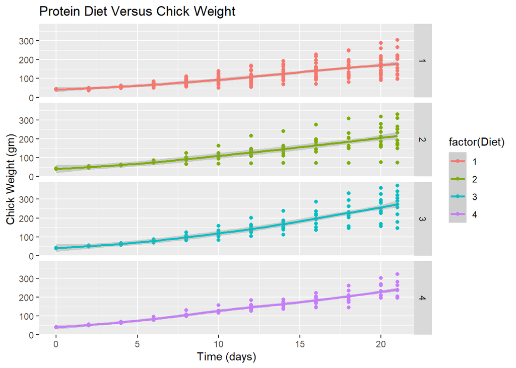

```r
qplot(Time, weight, data=ChickWeight, color=factor(Diet), facets = Diet ~ .,
      geom=c("point", "smooth"),
      main="Protein Diet Versus Chick Weight ", xlab = "Time (days)", ylab = "Chick Weight (gm)" )
```

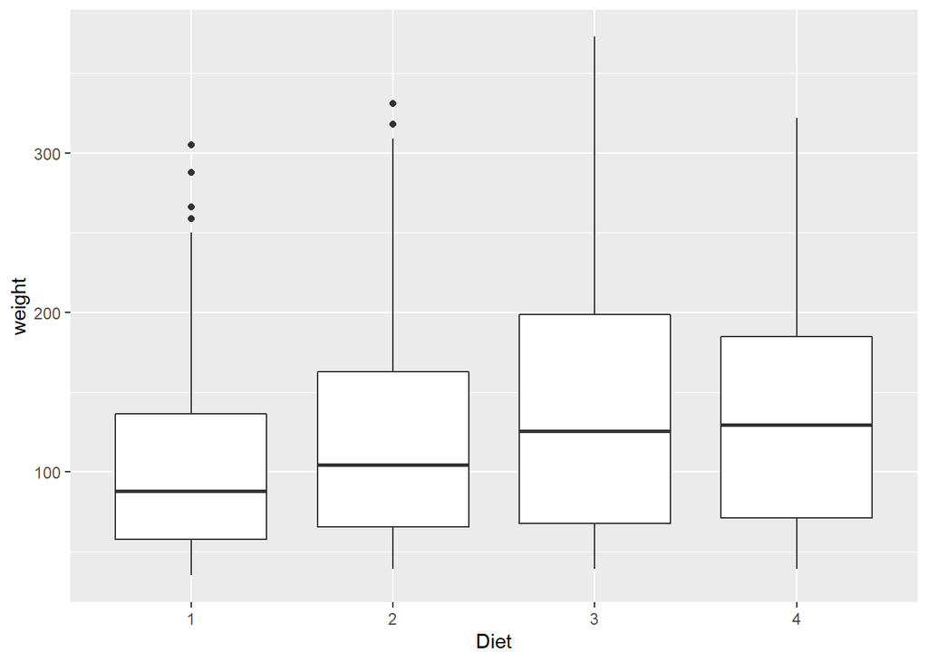

```r
ggplot(ChickWeight, aes(x=Diet, y=weight)) +
  geom_boxplot()
```

### DNase

**Loading Data / Basic Plotting Tutorial**

```r
library(ggplot2) #qplot (basic scatterplot)
library(ggthemes)
library(tidyverse)
library(datasets)
library(ggfortify)
library(rmarkdown)
```

?datasets library(help = “datasets”) ?DNase

The DNase data frame has 176 rows and 3 columns of data obtained during development of an ELISA assay for the recombinant protein DNase in rat serum.

DNase head(DNase)

class(DNase) #data frame

Looking at distribution of data

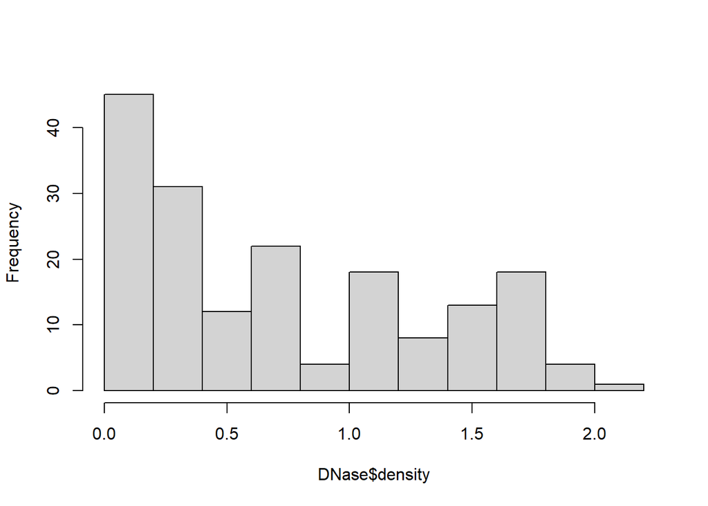

```r
par(mfrow = c(1,1))
hist(DNase$density, breaks=10, main = "")
```

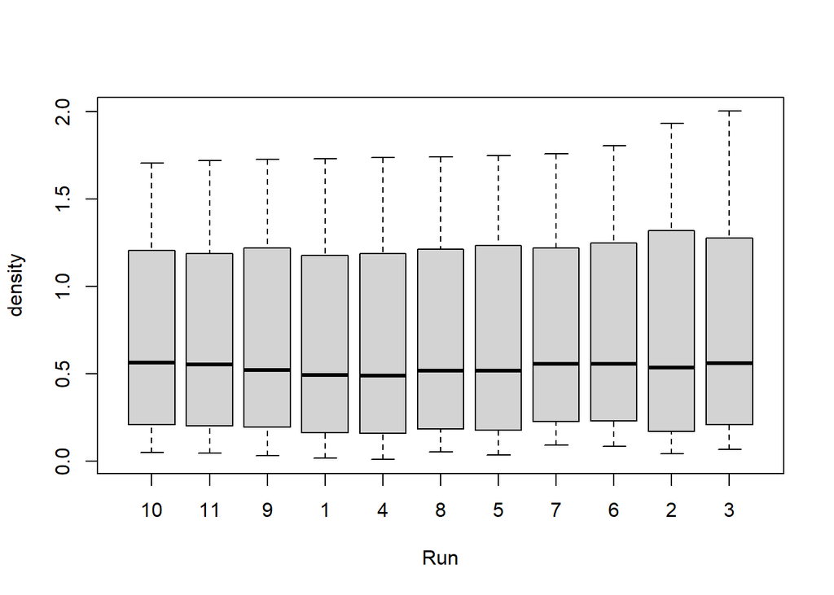

```r
boxplot(density ~ Run, data = DNase)
```

Plotting outliers

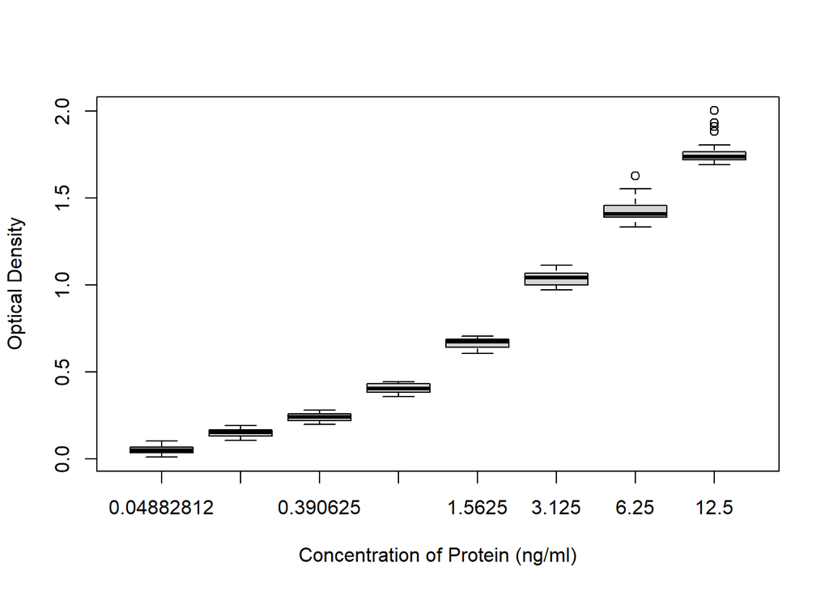

```r
par(mfrow = c(1,1))
boxplot(DNase$density~DNase$conc,xlab="Concentration of Protein (ng/ml)",ylab="Optical Density")
```

Finding outliers

```r
boxplot.stats(DNase$density[DNase$conc==12.5])$out
```

```
## [1] 1.932 1.914 2.003 1.884
```

```r
boxplot.stats(DNase$density[DNase$conc==6.25])$out
```

```
## [1] 1.629
```

Removing outliers

```r
df_no_outliers <- subset(x=DNase, !density %in% boxplot.stats(DNase$density[DNase$conc==12.5])$out & !density %in% boxplot.stats(DNase$density[DNase$conc==6.25])$out )
```

Final Graph

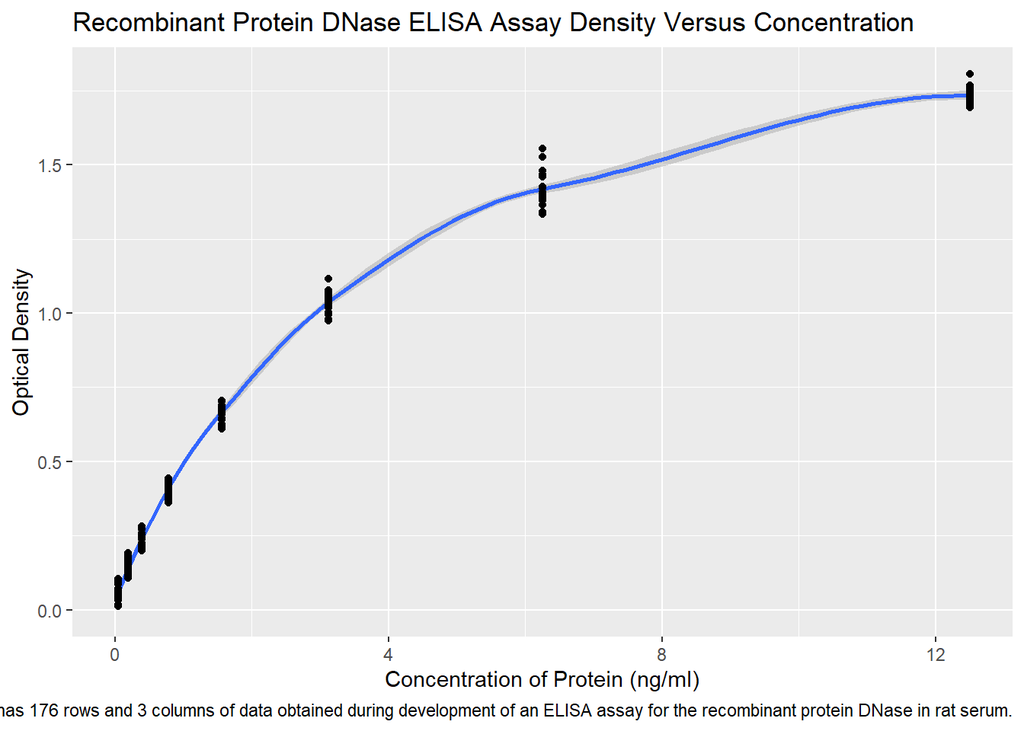

```r
ggplot(df_no_outliers, aes(x=conc, y=density)) +
  geom_smooth()+
  geom_point()+
  expand_limits(y=0, x=0)+
  labs(title="Recombinant Protein DNase ELISA Assay Density Versus Concentration", x = "Concentration of Protein (ng/ml)", y = "Optical Density",
       caption="The DNase data frame has 176 rows and 3 columns of data obtained during development of an ELISA assay for the recombinant protein DNase in rat serum.")
```

### EUStockMarkets

**Loading Data / Basic Plotting Tutorial**

```r
library(ggplot2) #qplot (basic scatterplot)
library(ggthemes)
library(tidyverse)
library(datasets)
library(ggfortify)
library(rmarkdown)
library(broom)
library(dplyr)
```

?datasets library(help = “datasets”) ?EuStockMarkets

Contains the daily closing prices of major European stock indices: Germany DAX (Ibis), Switzerland SMI, France CAC, and UK FTSE. The data are sampled in business time, i.e., weekends and holidays are omitted.

EuStockMarkets head(EuStockMarkets)

class(EuStockMarkets) #timeseries

```r
EuStockDF<-as.data.frame(EuStockMarkets)
EuStockDF$Date <- as.numeric(time(EuStockMarkets))
```

now the dates have an official column head(EuStockDF)

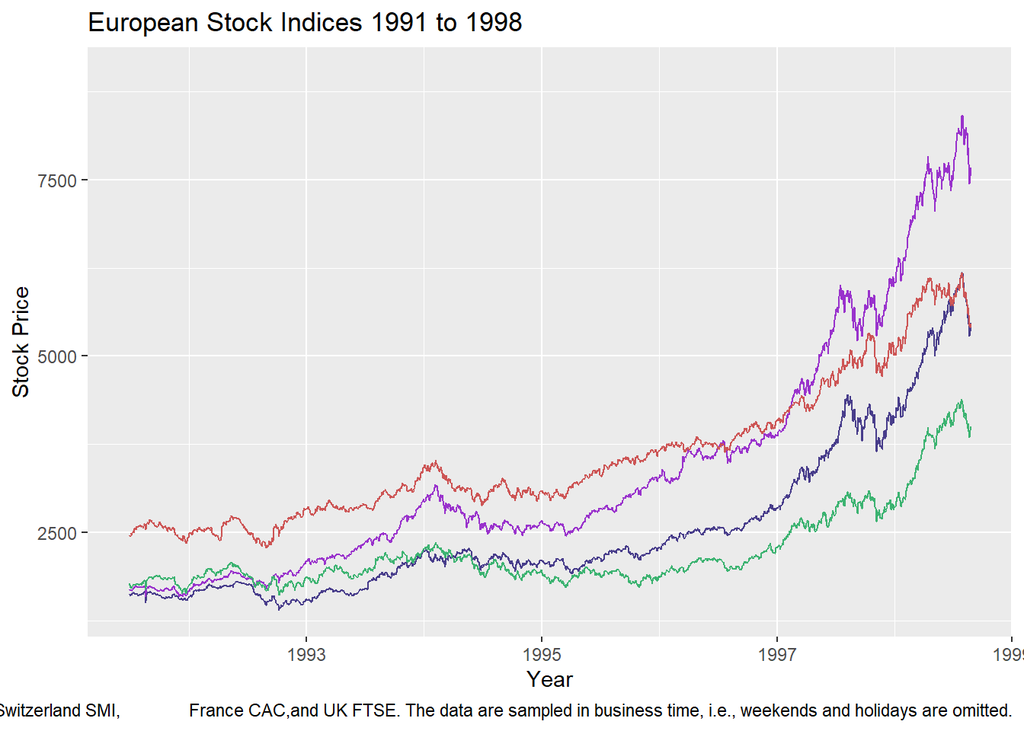

```r
ggplot(EuStockDF,aes(x = Date))+
  expand_limits(y=c(2000, 9000))+
  labs(title="European Stock Indices 1991 to 1998", x = "Year", y = "Stock Price",
       caption="Contains the daily closing prices of major European stock indices: Germany DAX (Ibis), Switzerland SMI,               France CAC,and UK FTSE. The data are sampled in business time, i.e., weekends and holidays are omitted.")+
  geom_line(aes(y = DAX), color="darkslateblue")+
  geom_line(aes(y = SMI), color="darkorchid")+
  geom_line(aes(y = CAC), color="mediumseagreen")+
  geom_line(aes(y = FTSE), color="indianred3")
```

```r
tidyEuStockMarkets <- tidy(EuStockMarkets)
tidyEuStockMarkets <- tidyEuStockMarkets %>%
  rename(Date=index,Stock_Index=series,Price=value)
```

```r
tidyEuStockMarkets
```

```
## # A tibble: 7,440 x 3
##     Date Stock_Index Price
##    <dbl> <chr>       <dbl>
##  1 1991. DAX         1629.
##  2 1991. SMI         1678.
##  3 1991. CAC         1773.
##  4 1991. FTSE        2444.
##  5 1992. DAX         1614.
##  6 1992. SMI         1688.
##  7 1992. CAC         1750.
##  8 1992. FTSE        2460.
##  9 1992. DAX         1607.
## 10 1992. SMI         1679.
## # ... with 7,430 more rows
## # i Use `print(n = ...)` to see more rows
```

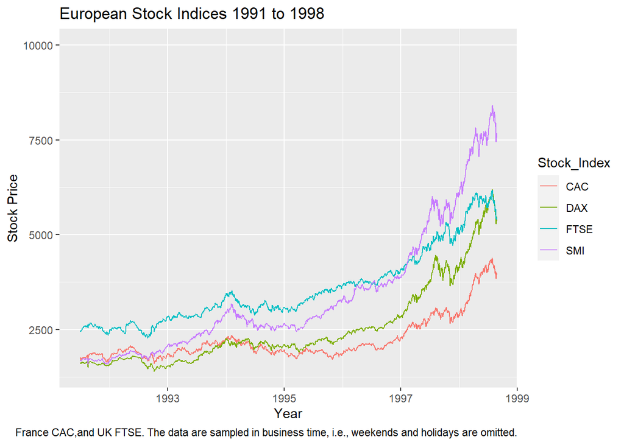

```r
ggplot(tidyEuStockMarkets,aes(x=Date,y=Price))+
  geom_line(aes(color=Stock_Index))+
  expand_limits(y=c(2000, 10000))+
  labs(title="European Stock Indices 1991 to 1998", x = "Year", y = "Stock Price",
       caption="Contains the daily closing prices of major European stock indices: Germany DAX (Ibis), Switzerland SMI,           France CAC,and UK FTSE. The data are sampled in business time, i.e., weekends and holidays are omitted.")
```

### HairEyeColor

**Loading Data / Basic Plotting Tutorial**

```r
library(ggplot2) #qplot (basic scatterplot)
library(ggthemes)
library(tidyverse)
library(datasets)
library(ggfortify)
library(rmarkdown)
```

?datasets library(help = “datasets”) ?HairEyeColor

#Distribution of hair and eye color and sex in 592 statistics students.

HairEyeColor head(HairEyeColor)

class(HairEyeColor) #table

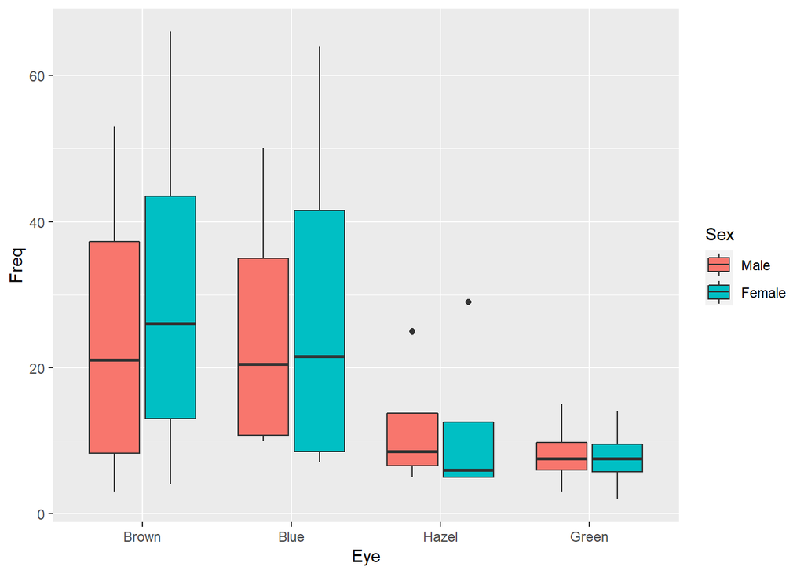

```r
ggplot(HairEyeColor, aes(Eye, Freq, fill=Sex))+
    geom_boxplot()
```

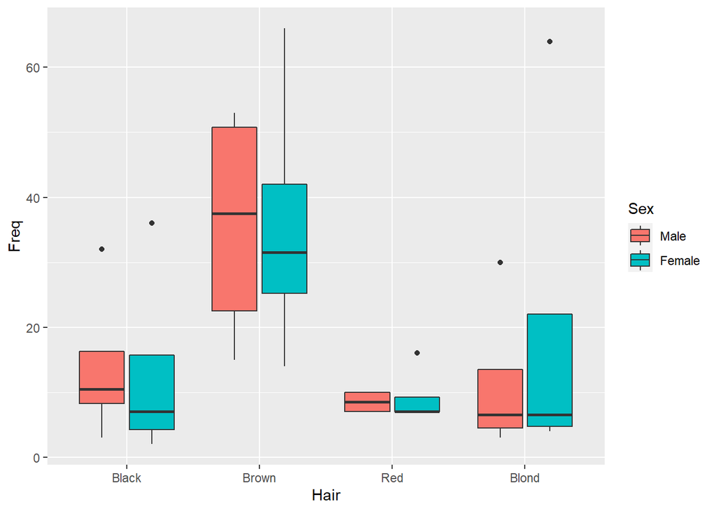

```r
ggplot(HairEyeColor, aes(Hair, Freq, fill=Sex))+
  geom_boxplot()
```

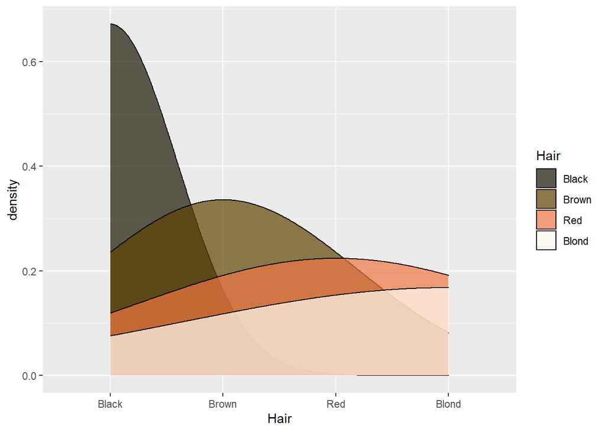

```r
ggplot(HairEyeColor, aes(Hair, fill=Hair))+
  scale_fill_manual(values=c("#1C1504", "#5E4303", "#F07743", "#FFFBF1"))+
  geom_density(alpha=0.7)
```

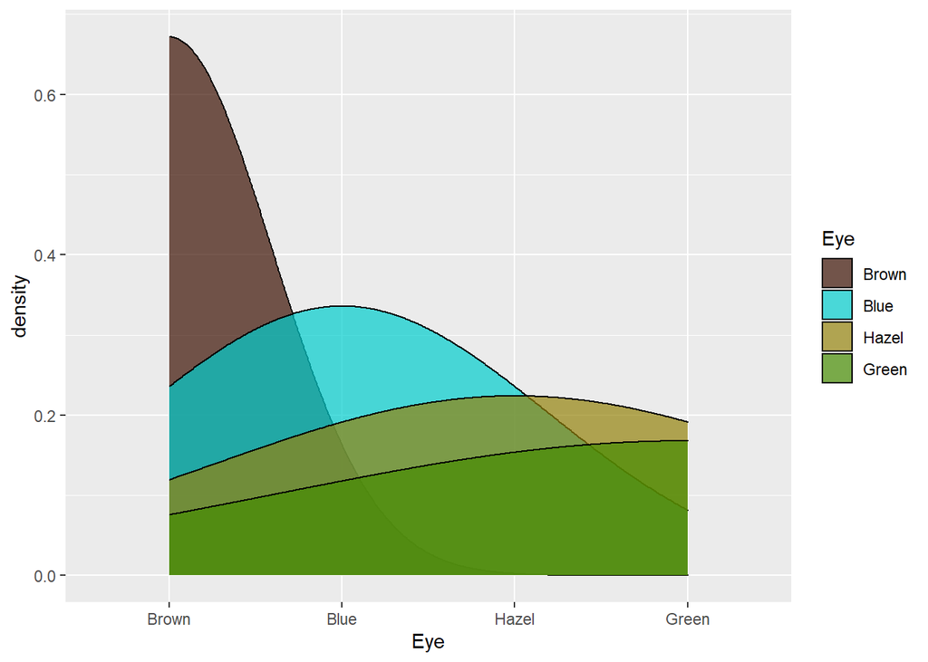

```r
ggplot(HairEyeColor, aes(Eye, fill=Eye,))+
  scale_fill_manual(values=c("#3B1002", "cyan3", "#93820B", "chartreuse4"))+
  geom_density(alpha=0.7)
```

```r
library(vcd)
```

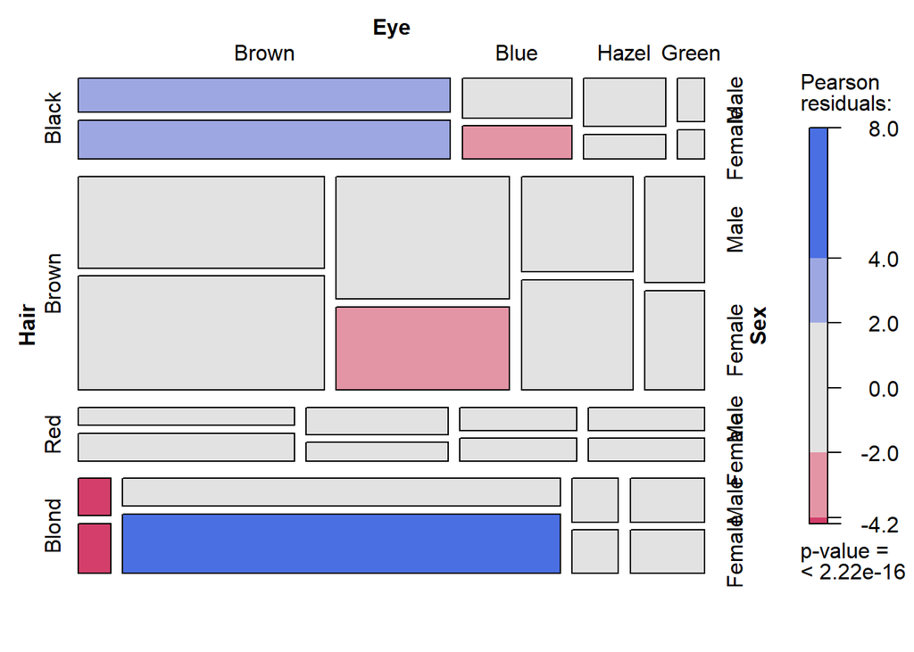

```r
mosaic(HairEyeColor, shade = TRUE)
```

```r
HairEyeColorchi <- HairEyeColor[,,"Male"] + HairEyeColor[,,"Female"]
HairEyeColorchi
```

```
##        Eye
## Hair    Brown Blue Hazel Green
##   Black    68   20    15     5
##   Brown   119   84    54    29
##   Red      26   17    14    14
##   Blond     7   94    10    16
```

```r
#p-value < 2.2e-16 significant
chisq.test(HairEyeColorchi)
```

```
##
##  Pearson's Chi-squared test
##
## data:  HairEyeColorchi
## X-squared = 138.29, df = 9, p-value < 2.2e-16
```

HairEyeColorchi/sum

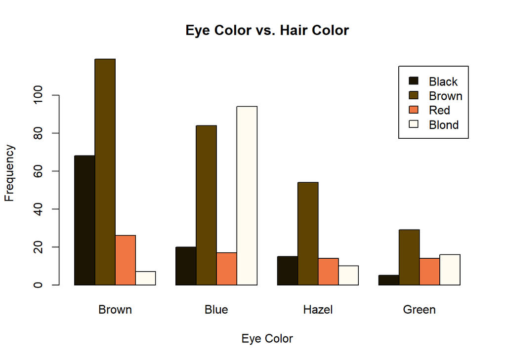

```r
barplot(HairEyeColorchi, beside=TRUE, legend.text=TRUE, xlab="Eye Color", ylab="Frequency", main="Eye Color vs. Hair Color",
        col=c("#1C1504", "#5E4303", "#F07743", "#FFFBF1"))
```

HairEyeColor

```r
#2 means columns, 1 means rows
MH <- apply(HairEyeColor[,,"Male"],1,sum)
MH
```

```
## Black Brown   Red Blond
##    56   143    34    46
```

```r
FH <- apply(HairEyeColor[,,"Female"],1,sum)
FH
```

```
## Black Brown   Red Blond
##    52   143    37    81
```

```r
HairEyeColorchi2 <- cbind(MH,FH)
HairEyeColorchi2
```

```
##        MH  FH
## Black  56  52
## Brown 143 143
## Red    34  37
## Blond  46  81
```

```r
#p-value = 0.04613 somehwta significant
chisq.test(HairEyeColorchi2)
```

```
##
##  Pearson's Chi-squared test
##
## data:  HairEyeColorchi2
## X-squared = 7.9942, df = 3, p-value = 0.04613
```

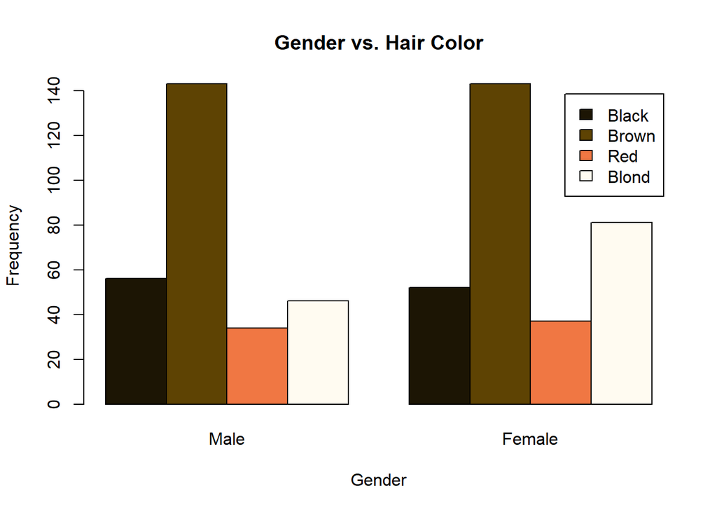

```r
barplot(HairEyeColorchi2, beside=TRUE, legend.text=TRUE, xlab="Gender", ylab="Frequency", main="Gender vs. Hair Color",
        names.arg=c("Male","Female"), col=c("#1C1504", "#5E4303", "#F07743", "#FFFBF1"))
```

HairEyeColor

```r
#2 means columns, 1 means rows
ME <- apply(HairEyeColor[,,"Male"],2,sum)
FE <- apply(HairEyeColor[,,"Female"],2,sum)
HairEyeColorchi3 <- cbind(ME,FE)

HairEyeColorchi3
```

```
##        ME  FE
## Brown  98 122
## Blue  101 114
## Hazel  47  46
## Green  33  31
```

```r
#p-value = 0.6754 not significant
chisq.test(HairEyeColorchi3)
```

```
##
##  Pearson's Chi-squared test
##
## data:  HairEyeColorchi3
## X-squared = 1.5298, df = 3, p-value = 0.6754
```

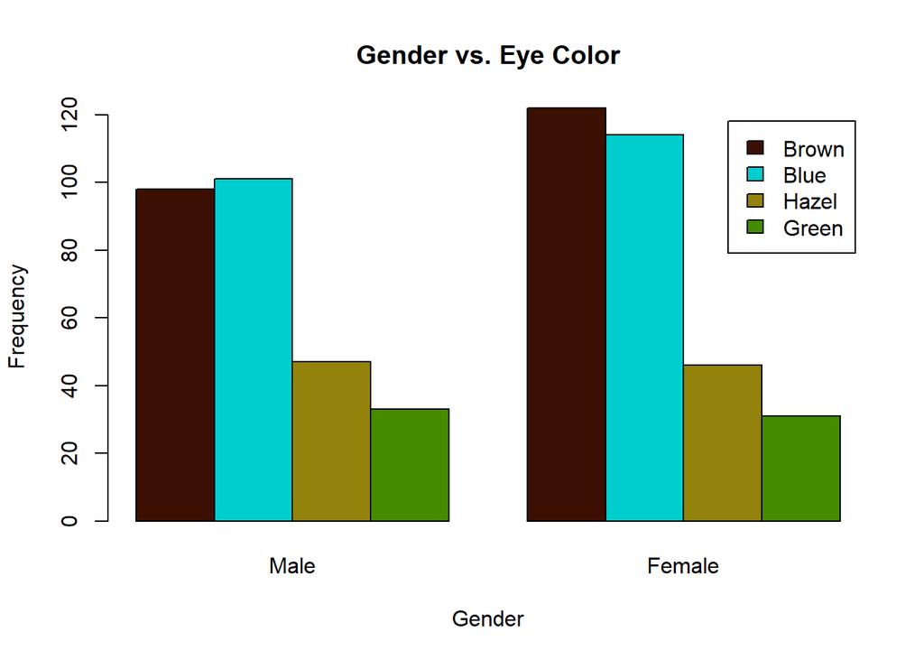

```r
barplot(HairEyeColorchi3, beside=TRUE, legend.text=TRUE, xlab="Gender", ylab="Frequency", main="Gender vs. Eye Color",
        names.arg=c("Male","Female"), col=c("#3B1002", "cyan3", "#93820B", "chartreuse4"))
```

### Harman23.cor

**Loading Data / Basic Plotting Tutorial**

```r
library(ggplot2) #qplot (basic scatterplot)
library(ggthemes)
library(tidyverse)
library(datasets)
library(ggfortify)
library(rmarkdown)
library(ggcorrplot)
```

?datasets library(help = “datasets”) ?Harman23.cor

A correlation matrix of eight physical measurements on 305 girls between ages seven and seventeen.

```r
Harman23.cor
```

```
## $cov
##                height arm.span forearm lower.leg weight bitro.diameter
## height          1.000    0.846   0.805     0.859  0.473          0.398
## arm.span        0.846    1.000   0.881     0.826  0.376          0.326
## forearm         0.805    0.881   1.000     0.801  0.380          0.319
## lower.leg       0.859    0.826   0.801     1.000  0.436          0.329
## weight          0.473    0.376   0.380     0.436  1.000          0.762
## bitro.diameter  0.398    0.326   0.319     0.329  0.762          1.000
## chest.girth     0.301    0.277   0.237     0.327  0.730          0.583
## chest.width     0.382    0.415   0.345     0.365  0.629          0.577
##                chest.girth chest.width
## height               0.301       0.382
## arm.span             0.277       0.415
## forearm              0.237       0.345
## lower.leg            0.327       0.365
## weight               0.730       0.629
## bitro.diameter       0.583       0.577
## chest.girth          1.000       0.539
## chest.width          0.539       1.000
##
## $center
## [1] 0 0 0 0 0 0 0 0
##
## $n.obs
## [1] 305
```

```r
head(Harman23.cor)
```

```
## $cov
##                height arm.span forearm lower.leg weight bitro.diameter
## height          1.000    0.846   0.805     0.859  0.473          0.398
## arm.span        0.846    1.000   0.881     0.826  0.376          0.326
## forearm         0.805    0.881   1.000     0.801  0.380          0.319
## lower.leg       0.859    0.826   0.801     1.000  0.436          0.329
## weight          0.473    0.376   0.380     0.436  1.000          0.762
## bitro.diameter  0.398    0.326   0.319     0.329  0.762          1.000
## chest.girth     0.301    0.277   0.237     0.327  0.730          0.583
## chest.width     0.382    0.415   0.345     0.365  0.629          0.577
##                chest.girth chest.width
## height               0.301       0.382
## arm.span             0.277       0.415
## forearm              0.237       0.345
## lower.leg            0.327       0.365
## weight               0.730       0.629
## bitro.diameter       0.583       0.577
## chest.girth          1.000       0.539
## chest.width          0.539       1.000
##
## $center
## [1] 0 0 0 0 0 0 0 0
##
## $n.obs
## [1] 305
```

```r
class(Harman23.cor) #list
```

```
## [1] "list"
```

Exporting file to csv so I can manipulate it to work more easily with corrplot getwd() write.csv(Harman23.cor,“C:/Users/Siggi/Downloads/Harman23.cor.csv”, row.names = FALSE)

```r
Harman23DF <- as.data.frame(Harman23.cor,  col.names = c("", "", ""))#dataframe now
Harman23DF #dataframe now so ggcorrplot will work
```

```
##                height arm.span forearm lower.leg weight bitro.diameter
## height          1.000    0.846   0.805     0.859  0.473          0.398
## arm.span        0.846    1.000   0.881     0.826  0.376          0.326
## forearm         0.805    0.881   1.000     0.801  0.380          0.319
## lower.leg       0.859    0.826   0.801     1.000  0.436          0.329
## weight          0.473    0.376   0.380     0.436  1.000          0.762
## bitro.diameter  0.398    0.326   0.319     0.329  0.762          1.000
## chest.girth     0.301    0.277   0.237     0.327  0.730          0.583
## chest.width     0.382    0.415   0.345     0.365  0.629          0.577
##                chest.girth chest.width c.0..0..0..0..0..0..0..0. X305
## height               0.301       0.382                         0  305
## arm.span             0.277       0.415                         0  305
## forearm              0.237       0.345                         0  305
## lower.leg            0.327       0.365                         0  305
## weight               0.730       0.629                         0  305
## bitro.diameter       0.583       0.577                         0  305
## chest.girth          1.000       0.539                         0  305
## chest.width          0.539       1.000                         0  305
```

```r
class(Harman23DF)
```

```
## [1] "data.frame"
```

Anything correlated to itself will be 1 so ignore middle diagonal and anything paired to itself

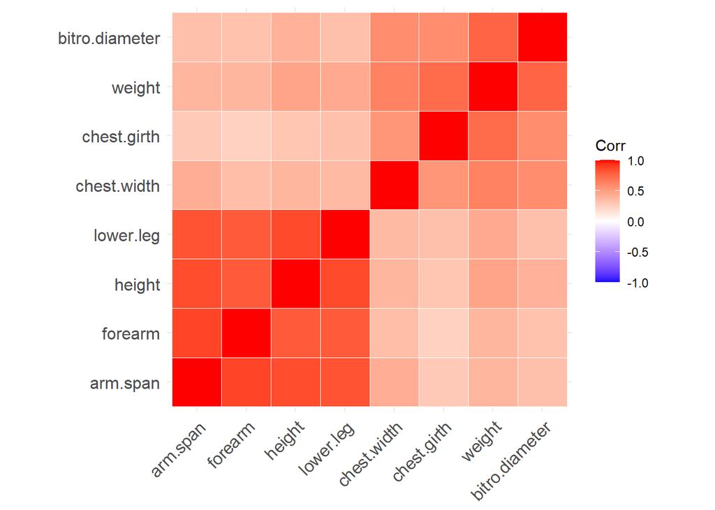

```r
ggcorrplot(Harman23DF, hc.order = TRUE, outline.col = "white")
```

```r
library(corrplot)
#removing unnecessary columns
Harman23DF$c.0..0..0..0..0..0..0..0. <- NULL
Harman23DF$X305 <- NULL
Harman23DF
```

```
##                height arm.span forearm lower.leg weight bitro.diameter
## height          1.000    0.846   0.805     0.859  0.473          0.398
## arm.span        0.846    1.000   0.881     0.826  0.376          0.326
## forearm         0.805    0.881   1.000     0.801  0.380          0.319
## lower.leg       0.859    0.826   0.801     1.000  0.436          0.329
## weight          0.473    0.376   0.380     0.436  1.000          0.762
## bitro.diameter  0.398    0.326   0.319     0.329  0.762          1.000
## chest.girth     0.301    0.277   0.237     0.327  0.730          0.583
## chest.width     0.382    0.415   0.345     0.365  0.629          0.577
##                chest.girth chest.width
## height               0.301       0.382
## arm.span             0.277       0.415
## forearm              0.237       0.345
## lower.leg            0.327       0.365
## weight               0.730       0.629
## bitro.diameter       0.583       0.577
## chest.girth          1.000       0.539
## chest.width          0.539       1.000
```

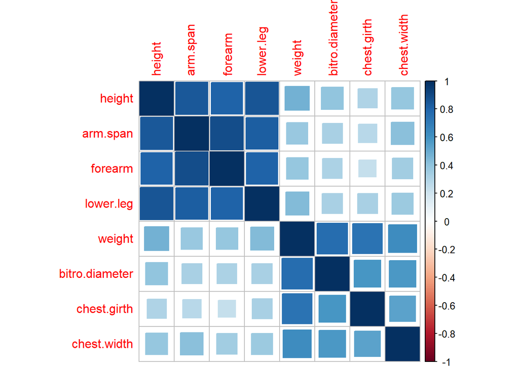

```r
corrplot(as.matrix(Harman23DF), is.corr = TRUE, method = "square")
```

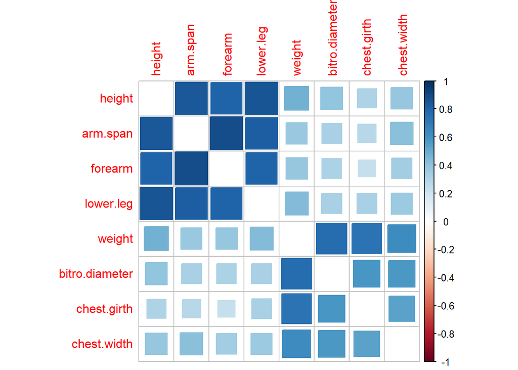

```r
corrplot(as.matrix(Harman23DF), is.corr = TRUE, method = "square", diag = FALSE)
```

```r
testHarman23DF = cor.mtest(Harman23DF, conf.level = 0.95)
testHarman23DF
```

```
## $p
##                      height     arm.span      forearm    lower.leg      weight
## height         0.0000000000 4.579308e-04 8.728689e-04 0.0001847906 0.027700238
## arm.span       0.0004579308 0.000000e+00 4.333368e-05 0.0006216409 0.004772576
## forearm        0.0008728689 4.333368e-05 0.000000e+00 0.0009913897 0.008574570
## lower.leg      0.0001847906 6.216409e-04 9.913897e-04 0.0000000000 0.018631694
## weight         0.0277002379 4.772576e-03 8.574570e-03 0.0186316940 0.000000000
## bitro.diameter 0.0317509548 9.406004e-03 1.483709e-02 0.0123784231 0.009993784
## chest.girth    0.0059682247 2.779410e-03 2.601843e-03 0.0121484562 0.016784732
## chest.width    0.0448369232 7.425068e-02 4.805126e-02 0.0398602049 0.189857892
##                bitro.diameter chest.girth chest.width
## height            0.031750955 0.005968225  0.04483692
## arm.span          0.009406004 0.002779410  0.07425068
## forearm           0.014837090 0.002601843  0.04805126
## lower.leg         0.012378423 0.012148456  0.03986020
## weight            0.009993784 0.016784732  0.18985789
## bitro.diameter    0.000000000 0.104803965  0.21853563
## chest.girth       0.104803965 0.000000000  0.26562514
## chest.width       0.218535632 0.265625144  0.00000000
##
## $lowCI
##                    height   arm.span    forearm  lower.leg     weight
## height          1.0000000  0.7075883  0.6465730  0.7776590 -0.9544454
## arm.span        0.7075883  1.0000000  0.8584361  0.6799248 -0.9765496
## forearm         0.6465730  0.8584361  1.0000000  0.6333185 -0.9709085
## lower.leg       0.7776590  0.6799248  0.6333185  1.0000000 -0.9609777
## weight         -0.9544454 -0.9765496 -0.9709085 -0.9609777  1.0000000
## bitro.diameter -0.9519096 -0.9698878 -0.9642406 -0.9666167  0.3147889
## chest.girth    -0.9745527 -0.9807106 -0.9811615 -0.9668523  0.2221893
## chest.width    -0.9447176 -0.9317223 -0.9431240 -0.9473045 -0.2956608
##                bitro.diameter chest.girth chest.width
## height             -0.9519096  -0.9745527  -0.9447176
## arm.span           -0.9698878  -0.9807106  -0.9317223
## forearm            -0.9642406  -0.9811615  -0.9431240
## lower.leg          -0.9666167  -0.9668523  -0.9473045
## weight              0.3147889   0.2221893  -0.2956608
## bitro.diameter      1.0000000  -0.1586043  -0.3287749
## chest.girth        -0.1586043   1.0000000  -0.3750832
## chest.width        -0.3287749  -0.3750832   1.0000000
##
## $uppCI
##                     height    arm.span     forearm   lower.leg     weight
## height          1.00000000  0.98977320  0.98719781  0.99252006 -0.1257605
## arm.span        0.98977320  1.00000000  0.99543787  0.98862792 -0.4333915
## forearm         0.98719781  0.99543787  1.00000000  0.98661384 -0.3406765
## lower.leg       0.99252006  0.98862792  0.98661384  1.00000000 -0.2026428
## weight         -0.12576053 -0.43339147 -0.34067649 -0.20264283  1.0000000
## bitro.diameter -0.09837645 -0.32511523 -0.24489920 -0.27749097  0.9691978
## chest.girth    -0.39920171 -0.51003849 -0.51881885 -0.28081167  0.9625137
## chest.width    -0.02715660  0.08157119 -0.01254391 -0.05174479  0.8953537
##                bitro.diameter chest.girth chest.width
## height            -0.09837645  -0.3992017 -0.02715660
## arm.span          -0.32511523  -0.5100385  0.08157119
## forearm           -0.24489920  -0.5188189 -0.01254391
## lower.leg         -0.27749097  -0.2808117 -0.05174479
## weight             0.96919778   0.9625137  0.89535365
## bitro.diameter     1.00000000   0.9206218  0.88783153
## chest.girth        0.92062183   1.0000000  0.87609576
## chest.width        0.88783153   0.8760958  1.00000000
```

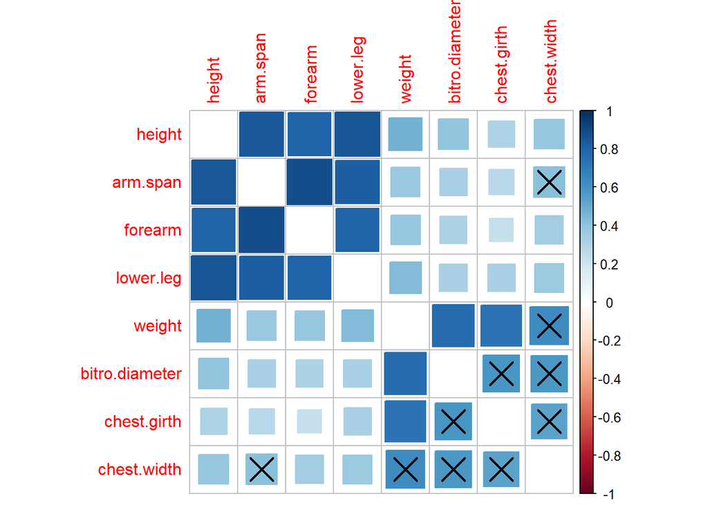

```r
#could not get this to work perfectly
corrplot(as.matrix(Harman23DF), is.corr = TRUE, method = "square", diag = FALSE, p.mat = testHarman23DF$p, sig.level = 0.05)
```

Main problem was reformatting original dataset to work with the corrplot function

### mtcars

**Loading Data / Basic Plotting Tutorial**

```r
library(ggplot2) #qplot (basic scatterplot)
library(ggthemes)
library(tidyverse)
library(datasets)
library(ggfortify)
library(rmarkdown)
library(ggcorrplot)
```

?datasets library(help = “datasets”) ?mtcars

The data was extracted from the 1974 Motor Trend US magazine, and comprises fuel consumption and 10 aspects of automobile design and performance for 32 automobiles (1973–74 models).

mtcars head(mtcars)

Only would do this if I want to export file to csv so I can manipulate it to work more easily with corrplot / renaming getwd() write.csv(mtcars,“C:/Users/Siggi/Downloads/mtcars.csv”, row.names = FALSE)

renaming columns

```r
mtcarsnew <- rename(mtcars, "# Gears" = gear, "# Carburetors" = carb, Transmission = am,
                    Engine = vs, "1/4 Mile Time" = qsec, Weight = wt, "Rear Axle Ratio" = drat,
                    Horsepower = hp, Displacement = disp, "# Cylinders" = cyl, MPG = mpg)
```

mtcarsnew

```r
class(mtcarsnew) #data frame
```

```
## [1] "data.frame"
```

```r
mtcarsCOR = cor(mtcarsnew)
mtcarsCOR
```

```
##                        MPG # Cylinders Displacement Horsepower Rear Axle Ratio
## MPG              1.0000000  -0.8521620   -0.8475514 -0.7761684      0.68117191
## # Cylinders     -0.8521620   1.0000000    0.9020329  0.8324475     -0.69993811
## Displacement    -0.8475514   0.9020329    1.0000000  0.7909486     -0.71021393
## Horsepower      -0.7761684   0.8324475    0.7909486  1.0000000     -0.44875912
## Rear Axle Ratio  0.6811719  -0.6999381   -0.7102139 -0.4487591      1.00000000
## Weight          -0.8676594   0.7824958    0.8879799  0.6587479     -0.71244065
## 1/4 Mile Time    0.4186840  -0.5912421   -0.4336979 -0.7082234      0.09120476
## Engine           0.6640389  -0.8108118   -0.7104159 -0.7230967      0.44027846
## Transmission     0.5998324  -0.5226070   -0.5912270 -0.2432043      0.71271113
## # Gears          0.4802848  -0.4926866   -0.5555692 -0.1257043      0.69961013
## # Carburetors   -0.5509251   0.5269883    0.3949769  0.7498125     -0.09078980
##                     Weight 1/4 Mile Time     Engine Transmission    # Gears
## MPG             -0.8676594    0.41868403  0.6640389   0.59983243  0.4802848
## # Cylinders      0.7824958   -0.59124207 -0.8108118  -0.52260705 -0.4926866
## Displacement     0.8879799   -0.43369788 -0.7104159  -0.59122704 -0.5555692
## Horsepower       0.6587479   -0.70822339 -0.7230967  -0.24320426 -0.1257043
## Rear Axle Ratio -0.7124406    0.09120476  0.4402785   0.71271113  0.6996101
## Weight           1.0000000   -0.17471588 -0.5549157  -0.69249526 -0.5832870
## 1/4 Mile Time   -0.1747159    1.00000000  0.7445354  -0.22986086 -0.2126822
## Engine          -0.5549157    0.74453544  1.0000000   0.16834512  0.2060233
## Transmission    -0.6924953   -0.22986086  0.1683451   1.00000000  0.7940588
## # Gears         -0.5832870   -0.21268223  0.2060233   0.79405876  1.0000000
## # Carburetors    0.4276059   -0.65624923 -0.5696071   0.05753435  0.2740728
##                 # Carburetors
## MPG               -0.55092507
## # Cylinders        0.52698829
## Displacement       0.39497686
## Horsepower         0.74981247
## Rear Axle Ratio   -0.09078980
## Weight             0.42760594
## 1/4 Mile Time     -0.65624923
## Engine            -0.56960714
## Transmission       0.05753435
## # Gears            0.27407284
## # Carburetors      1.00000000
```

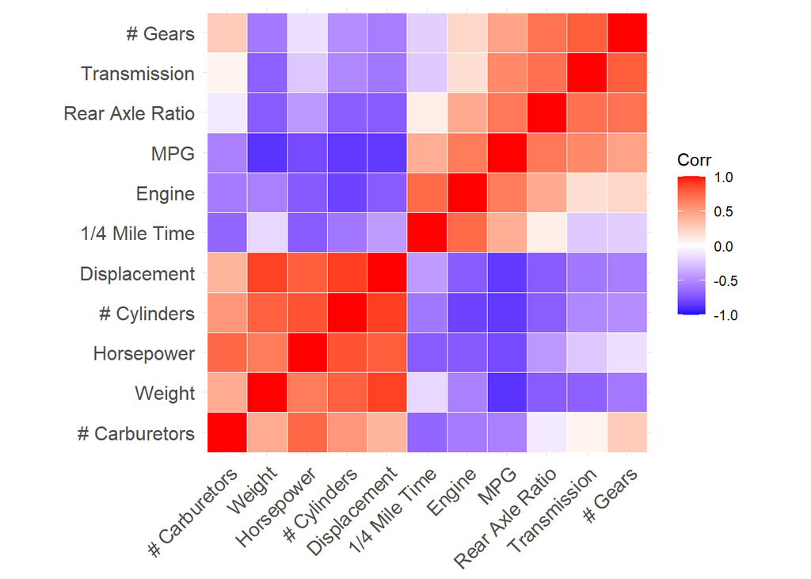

```r
ggcorrplot(mtcarsCOR, hc.order = TRUE, outline.col = "white")
```

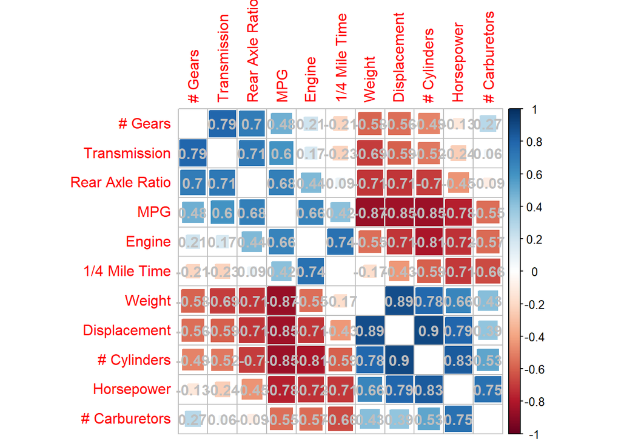

```r
corrplot(mtcarsCOR, is.corr = TRUE, method = "square", diag = FALSE, order = 'AOE', addCoef.col = "gray")
```

```r
testmtcarsCOR = cor.mtest(mtcarsCOR, conf.level = 0.95)
testmtcarsCOR
```

```
## $p
##                          MPG  # Cylinders Displacement   Horsepower
## MPG             0.000000e+00 4.037623e-09 1.091445e-09 4.322152e-06
## # Cylinders     4.037623e-09 0.000000e+00 1.659424e-09 5.625666e-07
## Displacement    1.091445e-09 1.659424e-09 0.000000e+00 1.304240e-05
## Horsepower      4.322152e-06 5.625666e-07 1.304240e-05 0.000000e+00
## Rear Axle Ratio 1.780708e-05 5.174268e-05 4.935086e-06 2.049276e-03
## Weight          2.518729e-08 1.320552e-06 1.901561e-08 1.787328e-04
## 1/4 Mile Time   1.471451e-02 5.949087e-03 1.829871e-02 3.509603e-04
## Engine          3.020659e-05 2.026977e-06 3.450779e-05 3.690380e-08
## Transmission    1.704116e-03 4.379896e-03 1.122485e-03 3.593445e-02
## # Gears         5.780693e-03 9.922460e-03 3.028291e-03 7.040180e-02
## # Carburetors   3.193816e-03 2.006581e-03 6.969729e-03 4.718601e-05
##                 Rear Axle Ratio       Weight 1/4 Mile Time       Engine
## MPG                1.780708e-05 2.518729e-08  1.471451e-02 3.020659e-05
## # Cylinders        5.174268e-05 1.320552e-06  5.949087e-03 2.026977e-06
## Displacement       4.935086e-06 1.901561e-08  1.829871e-02 3.450779e-05
## Horsepower         2.049276e-03 1.787328e-04  3.509603e-04 3.690380e-08
## Rear Axle Ratio    0.000000e+00 3.782478e-07  1.426220e-01 3.468419e-03
## Weight             3.782478e-07 0.000000e+00  5.627606e-02 4.608706e-04
## 1/4 Mile Time      1.426220e-01 5.627606e-02  0.000000e+00 1.673365e-04
## Engine             3.468419e-03 4.608706e-04  1.673365e-04 0.000000e+00
## Transmission       1.229604e-05 1.431601e-04  5.473798e-01 5.385274e-02
## # Gears            6.018579e-05 7.977054e-04  6.815004e-01 8.393306e-02
## # Carburetors      6.998155e-02 1.713296e-02  8.438162e-06 9.355873e-05
##                 Transmission      # Gears # Carburetors
## MPG             1.704116e-03 5.780693e-03  3.193816e-03
## # Cylinders     4.379896e-03 9.922460e-03  2.006581e-03
## Displacement    1.122485e-03 3.028291e-03  6.969729e-03
## Horsepower      3.593445e-02 7.040180e-02  4.718601e-05
## Rear Axle Ratio 1.229604e-05 6.018579e-05  6.998155e-02
## Weight          1.431601e-04 7.977054e-04  1.713296e-02
## 1/4 Mile Time   5.473798e-01 6.815004e-01  8.438162e-06
## Engine          5.385274e-02 8.393306e-02  9.355873e-05
## Transmission    0.000000e+00 1.702701e-07  3.055664e-01
## # Gears         1.702701e-07 0.000000e+00  4.848884e-01
## # Carburetors   3.055664e-01 4.848884e-01  0.000000e+00
##
## $lowCI
##                        MPG # Cylinders Displacement Horsepower Rear Axle Ratio
```

[output cut: 58 more lines]

```
## Transmission    -0.65992608    0.71623124  0.8803221   1.00000000  0.99463195
## # Gears         -0.52355311    0.68252616  0.8622780   0.99463195  1.00000000
## # Carburetors    0.91452061   -0.80994159 -0.6878237   0.32597570  0.42393232
##                 # Carburetors
## MPG               -0.38178798
## # Cylinders        0.95166303
## Displacement       0.93317802
## Horsepower         0.98053328
## Rear Axle Ratio    0.05241567
## Weight             0.91452061
## 1/4 Mile Time     -0.80994159
## Engine            -0.68782370
## Transmission       0.32597570
## # Gears            0.42393232
## # Carburetors      1.00000000
```

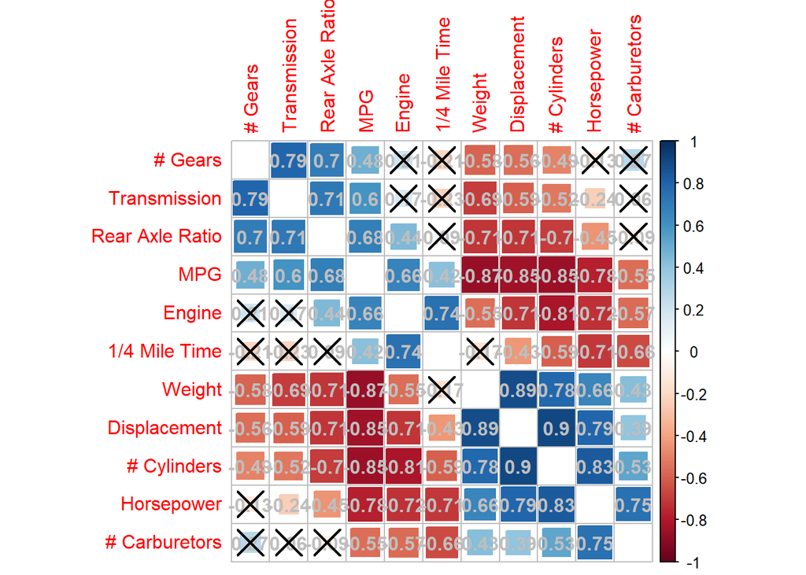

```r
corrplot(mtcarsCOR, is.corr = TRUE, method = "square", diag = FALSE, order = 'AOE', addCoef.col = "gray", p.mat = testmtcarsCOR$p, sig.level = 0.05)
```